# Analisis Data Stunting Provinsi Banten 2024 dan 2025

# Bar Chart

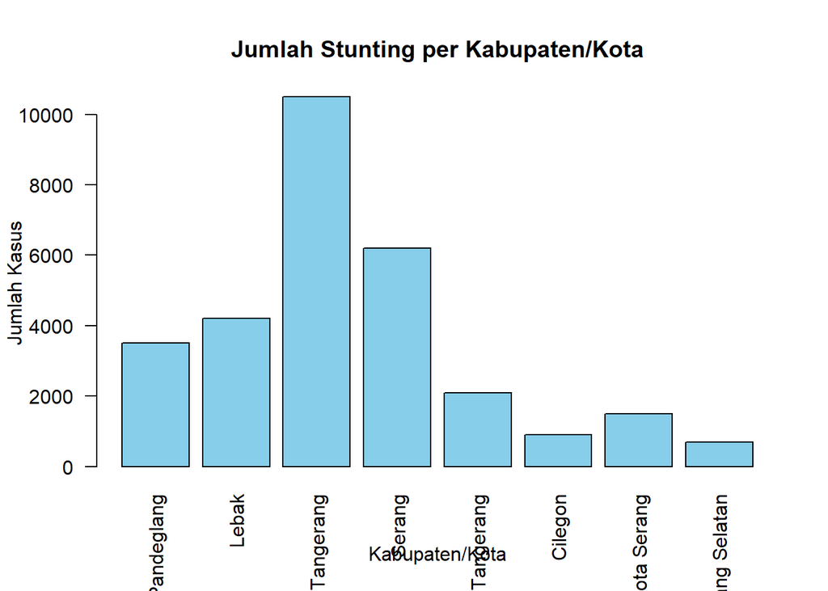

```r
barplot(total_stunting,
        names.arg = kabupaten,
        col = "skyblue",
        main = "Jumlah Stunting per Kabupaten/Kota",
        xlab = "Kabupaten/Kota",
        ylab = "Jumlah Kasus",
        las=2)
```

Interpretasi:

Grafik menunjukkan perbandingan jumlah kasus stunting di setiap kabupaten/kota di Provinsi Banten.

# Histogram

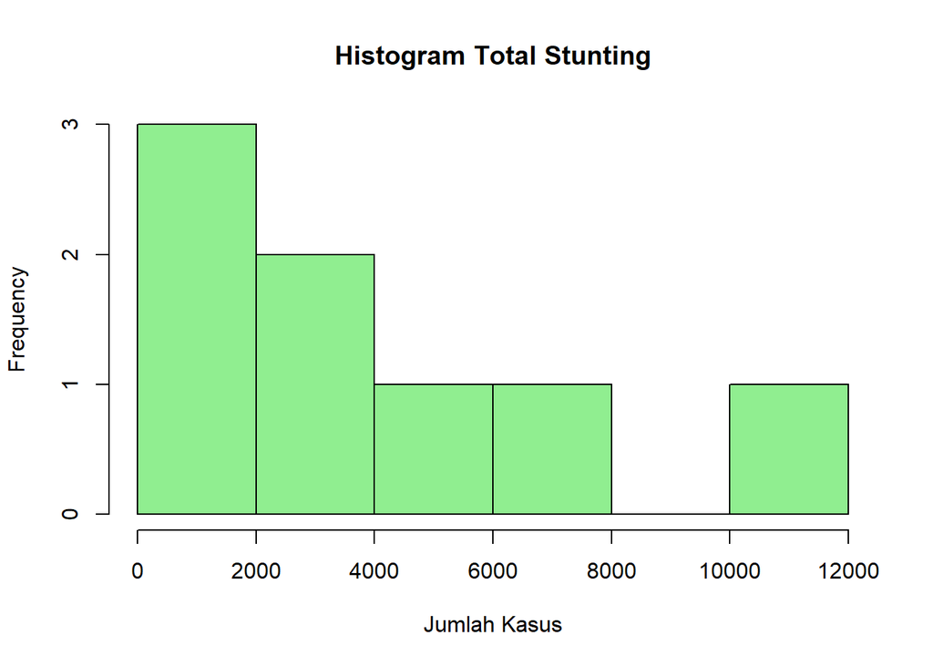

```r
hist(total_stunting,
     main="Histogram Total Stunting",
     xlab="Jumlah Kasus",
     col="lightgreen")
```

Interpretasi:

Histogram menunjukkan distribusi jumlah kasus stunting pada berbagai wilayah di Provinsi Banten.

# Density Plot

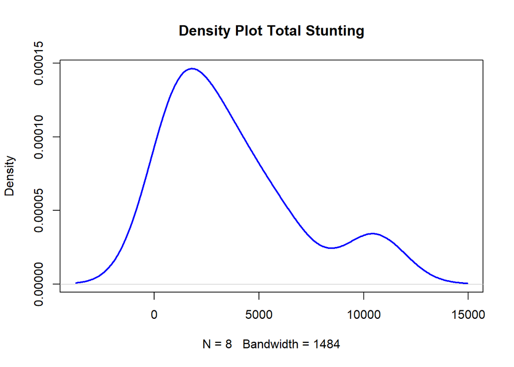

```r
plot(density(total_stunting),
     main="Density Plot Total Stunting",
     col="blue",
     lwd=2)
```

Interpretasi:

Density plot menunjukkan kepadatan distribusi jumlah kasus stunting.

# Boxplot

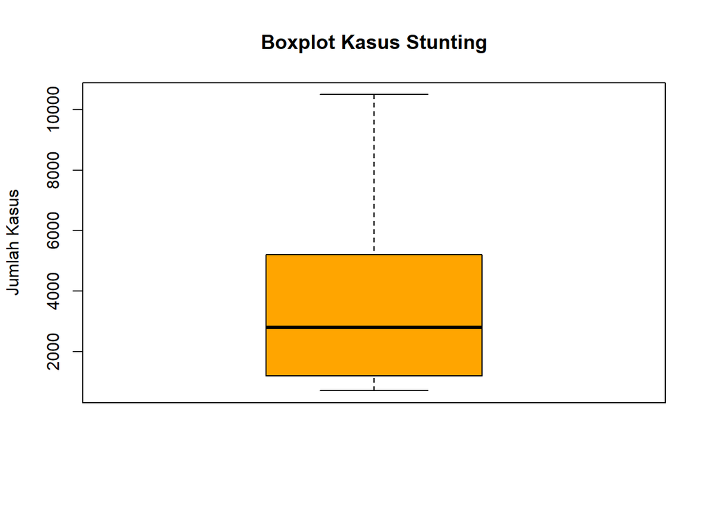

```r
boxplot(total_stunting,
        main="Boxplot Kasus Stunting",
        col="orange",
        ylab="Jumlah Kasus")
```

# Statistik Deskriptif

```r
mean(total_stunting)
```

```
## [1] 3700
```

```r
median(total_stunting)
```

```
## [1] 2800
```

```r
quantile(total_stunting)
```

```
##    0%   25%   50%   75%  100%
##   700  1350  2800  4700 10500
```

```r
range(total_stunting)
```

```
## [1]   700 10500
```

```r
var(total_stunting)
```

```
## [1] 11002857
```

```r
sd(total_stunting)
```

```
## [1] 3317.055
```

Penjelasan:

- Mean menunjukkan rata-rata jumlah kasus stunting.
- Median merupakan nilai tengah data.
- Kuartil menunjukkan pembagian data menjadi empat bagian.
- Range merupakan selisih antara nilai maksimum dan minimum.
- Varians dan standar deviasi menunjukkan tingkat penyebaran data.

# Kesimpulan

Berdasarkan analisis data stunting di Provinsi Banten, terdapat perbedaan jumlah kasus antar kabupaten/kota. Kabupaten Tangerang memiliki jumlah kasus tertinggi dibandingkan wilayah lainnya, sedangkan Tangerang Selatan memiliki jumlah kasus paling rendah.